# Wikipedon

2020-12-16

## Contexto

2020

- Implantação do curso
- Construção do projeto pedagógico de curso
- Inclusão de disciplinas de humanidades
- **Inclusão de atividades de extensão**
- **Atividades didáticas não presenciais**

[figure not shown]

Global Soil Partnership

1. Soil management
2. **Awareness raising**
3. Research
4. information & data
5. Harmonization

*Pillar 2: Encourage investment, technical cooperation, policy, education, awareness and extension in soil*

http://www.fao.org/global-soil-partnership/

[figure not shown]

Conteúdo sobre recursos do solo e da terra na Wikipédia

- Exemplo: Mariana, MG
- https://pt.wikipedia.org/wiki/Mariana

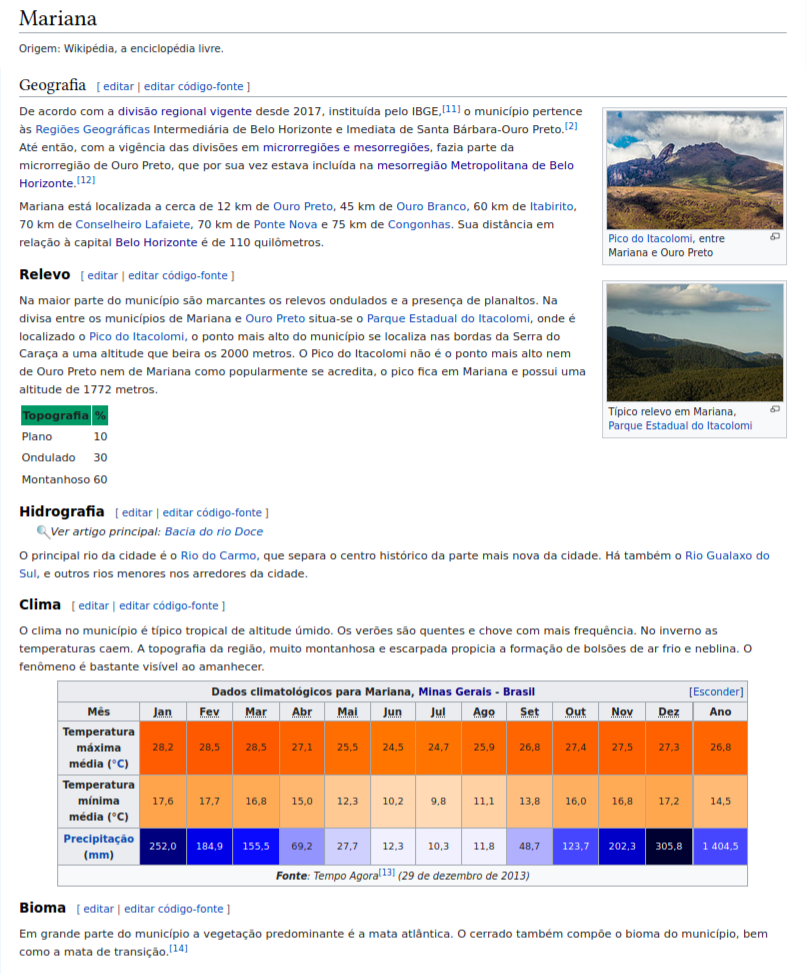

## Wikipedon

Pedon

- A menor unidade ou volume de solo que contém todas os horizontes e camadas de um tipo particular de solo
- Geralmente possui área superficial de um metro quadrado
- Se extende da superfície do terreno até a rocha subjascente

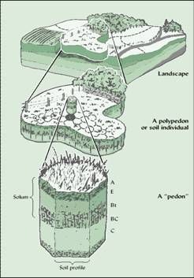

(Brady and Weil 2008)

AG63C Classificação do Solo

Após a conclusão bem sucedida dessa disciplina, espera-se que os discentes saibam **organizar** informações sobre o meio físico de extensões territoriais rurais, em especial a cobertura pedológica, selecionando variáveis, materiais e ferramentas que se apliquem ao contexto analisado, demonstrando atitude cooperativa e com comunicação efetiva.

- **encontrar** fontes confiáveis de informação do meio físico
- **sumariar** informações encontradas
- **reportar** relações existentes entre variáveis selecionadas
- **produzir** conteúdo digital sobre classificação de solos e terras para comunicação

**Tarefa:** Organizar informações sobre recursos do solo e da terra de minicípios brasileiros

- Geografia
  - Clima
  - Geologia
  - Relevo
  - Hidrografia
  - Vegetação
  - Solo

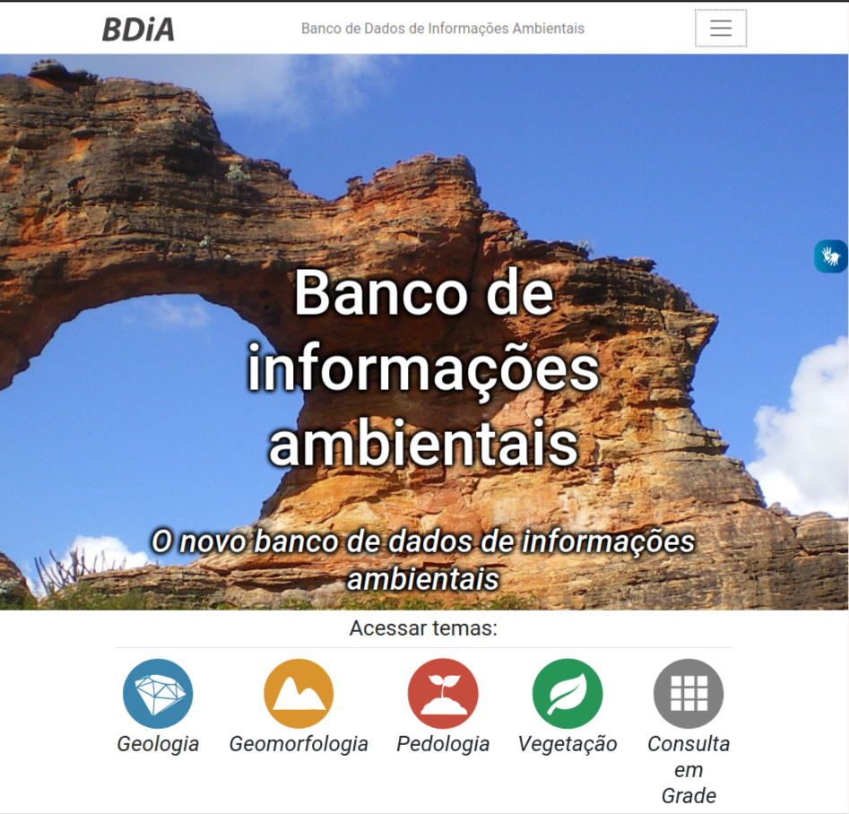

https://bdiaweb.ibge.gov.br

## Veja de perto!

- https://pt.wikiversity.org/wiki/Wikipedon

## Bibliografia

Brady, Nyle C., and Ray R. Weil. 2008. *The Nature and Properties of Soils*. 14th ed. Upper Saddle River, N.J: Pearson Prentice Hall.